# Bayesian modeling and prediction for movies

## Setup

The purpose of this project to develop a Baysean regression model to predict the audience_score from given explanatory and new created variables. The final model is expected to be optimized to use a fewer set of explanatory variables thus making it simpler and predict the good/accurate value for audience score. Details of steps taken to arrive at this model is explained below in steps.

### Load packages

```r
library(ggplot2)
library(dplyr)
library(statsr)
library(BAS)
library(GGally)
library(MASS)
```

### Load data

```r
load("movies.gz")
```

## Part 1: Data

The IMDb is an online information database of movies, TV programs and other titles, it also includes information of common interest like cast,summaries,etc. with data coming from various sources. The database also covers international titles. The sample database provided for this exercise filters out non-US movies and movies in the sample included are for the period 1970 onwards, whereas the IMDB database includes movie data since 1874 (approx 4.6million movies). The Rotten Tomatoes is a review aggregator site for film and TV.

Both databases contain observational data collected from various sources and due to their size and independent variety of sources could be categorized as random.

### Generalization and Causability

**The inferences from this exercise will have generalizability limited to the filters used in selecting the sample that is for US movies and limited to the period 1970-2016. The inferences will not be the basis of forming causal relationships due to lack of random assignment.**

## Part 2: Data manipulation

As required, the code below creates 5 new variables (feature_film, drama, summer_season,oscar_season & mpaa_rating_R) and initializes them from the sample movies data, populating them with ‘yes’ or ‘no’ based on conditions mentioned in the project exercise.

```r
movies <- movies %>% mutate (feature_film = ifelse (title_type == 'Feature Film','yes','no'))
movies$feature_film <- as.factor(movies$feature_film)


movies <- movies %>% mutate (drama = ifelse (genre == 'Drama','yes','no'))
movies$drama <- as.factor(movies$drama)


movies <- movies %>% mutate (summer_season = ifelse (thtr_rel_month %in% c(5,6,7,8),'yes','no'))
movies$summer_season <- as.factor(movies$summer_season)


movies <- movies %>% mutate (oscar_season = ifelse (thtr_rel_month %in% c(10,11,12),'yes','no'))
movies$oscar_season <- as.factor(movies$oscar_season)


movies <- movies %>% mutate (mpaa_rating_R = ifelse (mpaa_rating == 'R','yes','no'))
movies$mpaa_rating_R <- as.factor(movies$mpaa_rating_R)
```

## Part 3: Exploratory data analysis

We first study the influence of the 5 newly added variables. I have done this using a combination of inputs from the plots and statistics below:

The plots below provides a quick view of audience scores by each of the new variables added. In my explanation below, I refer to plots labelled (a) thru (f)

A summary of preliminary inference from the visuals and summary statistics, is below:

- Plot (a) - as seen from the histogram, the audience scores across all 5 variables have a wide range (11,97) with mean of 62.36 and standard deviation of 20.22
- Plot b,c,d,e,f - Feature movies and genre non-drama seem to have lower audience scores than feature and drama movies regardless of the season (oscar or summer). The impact of oscar season looks to be marginally better than summer season, but this would need to be validated statistically
- Plot (f) - it seems mpaa_rating has little impact on audience scores
- The number of non feature films in the sample dataset is relatively small compared to feature films (60 vs 591). The count though is still > 10 (meets the n(1-p) assumption for normal distribution) so valid for analysis.

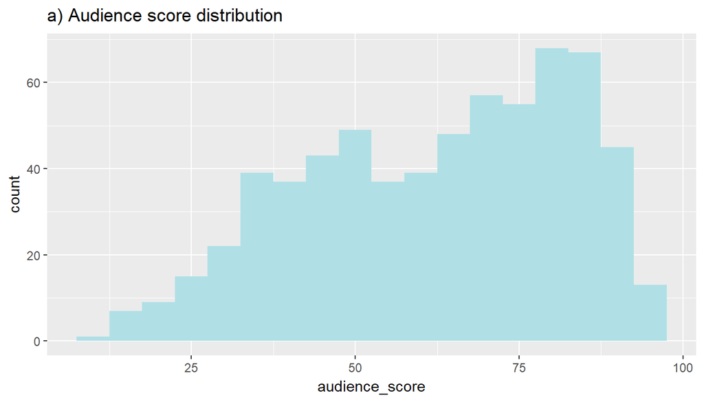

```r
ggplot(data= movies,aes(audience_score)) + geom_histogram(fill='powderblue', binwidth = 5) +  ggtitle('a) Audience score distribution')
```

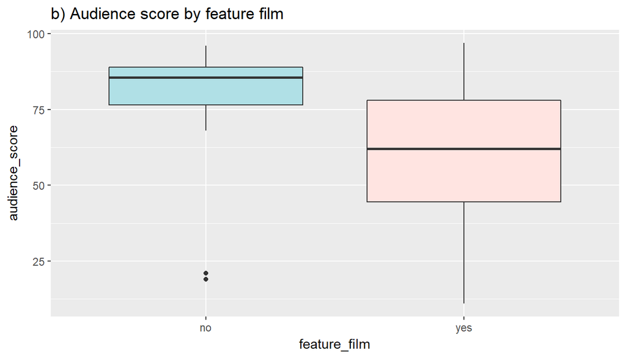

```r
ggplot(data= movies,aes(y=audience_score,x=feature_film)) + geom_boxplot(fill=c('powderblue','mistyrose')) +  ggtitle('b) Audience score by feature film')
```

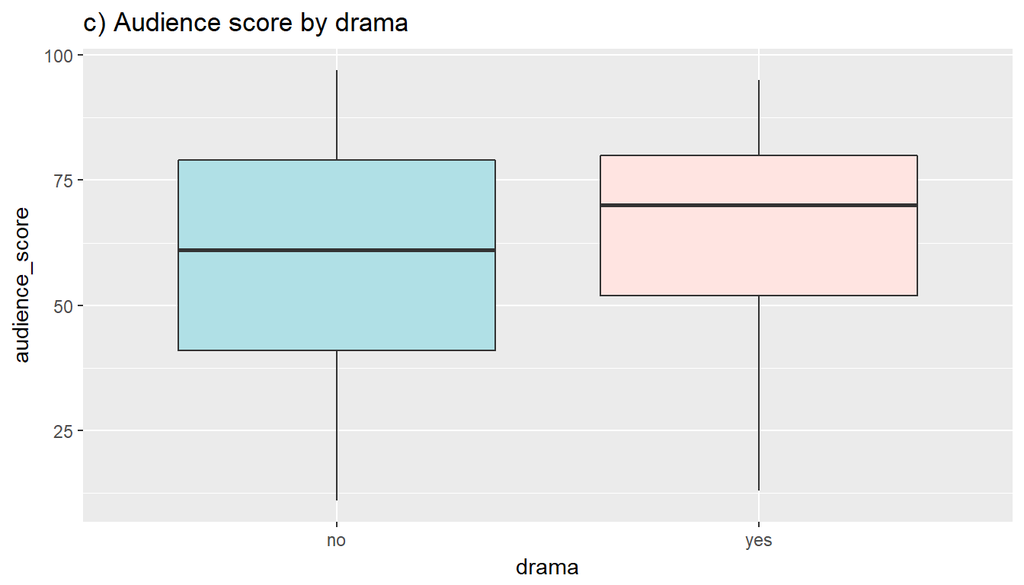

```r
ggplot(data= movies,aes(y=audience_score,x=drama)) +  geom_boxplot(fill=c('powderblue','mistyrose')) +  ggtitle('c) Audience score by drama')
```

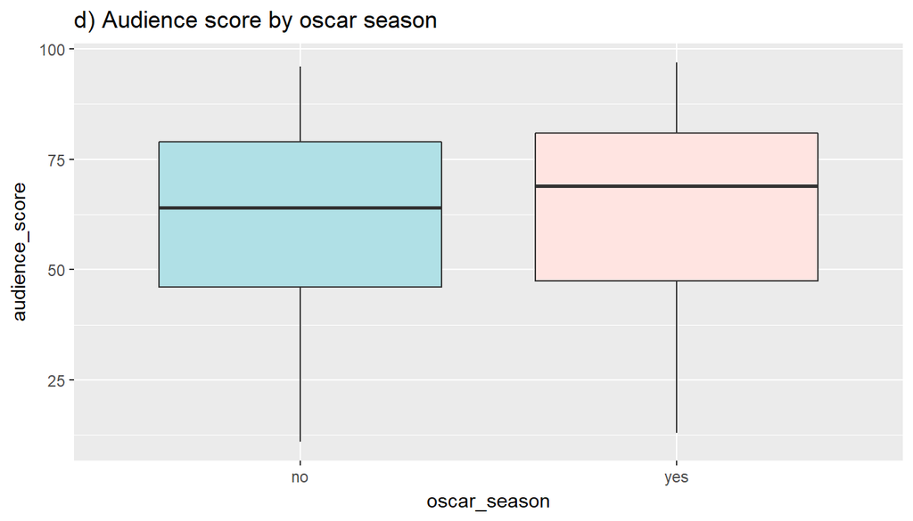

```r
ggplot(data= movies,aes(y=audience_score,x=oscar_season)) + geom_boxplot(fill=c('powderblue','mistyrose')) +  ggtitle('d) Audience score by oscar season')
```

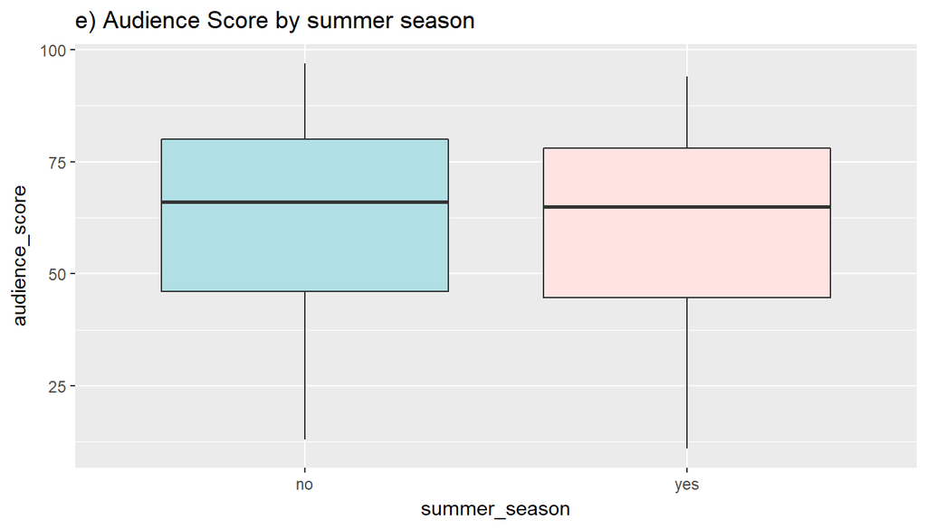

```r
ggplot(data= movies,aes(y=audience_score,x=summer_season)) + geom_boxplot(fill=c('powderblue','mistyrose')) +  ggtitle('e) Audience Score by summer season')
```

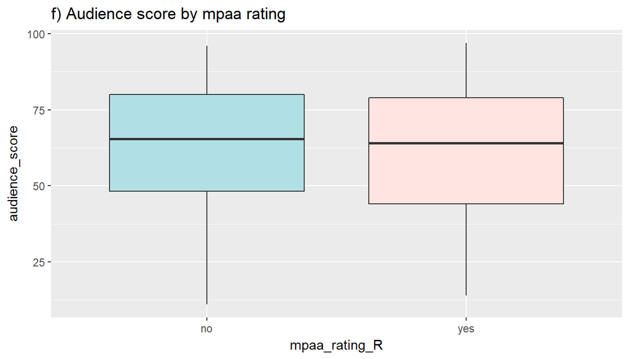

```r
ggplot(data= movies,aes(y=audience_score,x=mpaa_rating_R)) + geom_boxplot(fill=c('powderblue','mistyrose')) +  ggtitle('f) Audience score by mpaa rating')
```

Summary statistics for newly added variables is provided below giving the ‘yes’/‘no’ breakup of the 5 variables and basic statistics for audience scores. The dataframe is also reduced to the variables of interest, which is still a relatively large set of 16 variables and yet to be optimized.

```r
movies <- movies %>% dplyr::select (audience_score,feature_film,drama,mpaa_rating_R,oscar_season,summer_season,runtime,thtr_rel_year,imdb_rating,imdb_num_votes,critics_score,best_pic_nom,best_pic_win,best_actor_win,best_actress_win,best_dir_win,top200_box)
summary(movies[,1:6])
```

```
##  audience_score  feature_film drama     mpaa_rating_R oscar_season
##  Min.   :11.00   no : 60      no :346   no :322       no :460
##  1st Qu.:46.00   yes:591      yes:305   yes:329       yes:191
##  Median :65.00
##  Mean   :62.36
##  3rd Qu.:80.00
##  Max.   :97.00
##  summer_season
##  no :443
##  yes:208
##
##
##
##
```

**In summary, a non-feature, drama film scores higher on audience scores, all else being equal.**

## Part 4: Modeling

We start by taking a first look at how audience_score depends on all other variables (full model) using linear regression.

**Some observations below, from a frequentist approach looking at only ‘p’ values produced from linear regression:**

```r
lm_mod <- lm(audience_score ~.,data=movies)
summary (lm_mod)
```

```
##
## Call:
## lm(formula = audience_score ~ ., data = movies)
##
## Residuals:
##     Min      1Q  Median      3Q     Max
## -28.594  -6.156   0.157   5.909  53.125
##
## Coefficients:
##                       Estimate Std. Error t value Pr(>|t|)
## (Intercept)          1.244e+02  7.749e+01   1.606  0.10886
## feature_filmyes     -2.248e+00  1.687e+00  -1.332  0.18323
## dramayes             1.292e+00  8.766e-01   1.474  0.14087
## mpaa_rating_Ryes    -1.444e+00  8.127e-01  -1.777  0.07598 .
## oscar_seasonyes     -5.333e-01  9.967e-01  -0.535  0.59280
## summer_seasonyes     9.106e-01  9.493e-01   0.959  0.33778
## runtime             -5.614e-02  2.415e-02  -2.324  0.02042 *
## thtr_rel_year       -7.657e-02  3.835e-02  -1.997  0.04628 *
## imdb_rating          1.472e+01  6.067e-01  24.258  < 2e-16 ***
## imdb_num_votes       7.234e-06  4.523e-06   1.600  0.11019
## critics_score        5.748e-02  2.217e-02   2.593  0.00973 **
## best_pic_nomyes      5.321e+00  2.628e+00   2.025  0.04330 *
## best_pic_winyes     -3.212e+00  4.610e+00  -0.697  0.48624
## best_actor_winyes   -1.544e+00  1.179e+00  -1.310  0.19068
## best_actress_winyes -2.198e+00  1.304e+00  -1.686  0.09229 .
## best_dir_winyes     -1.231e+00  1.728e+00  -0.713  0.47630
## top200_boxyes        8.478e-01  2.782e+00   0.305  0.76067
## ---
## Signif. codes:  0 '***' 0.001 '**' 0.01 '*' 0.05 '.' 0.1 ' ' 1
##
## Residual standard error: 9.975 on 633 degrees of freedom
##   (1 observation deleted due to missingness)
## Multiple R-squared:  0.763,  Adjusted R-squared:  0.757
## F-statistic: 127.3 on 16 and 633 DF,  p-value: < 2.2e-16
```

As a next step, for variables with ‘p’ slightly above 0.05, I have used Bayes inference to test the null hypothesis **H_0: $\mu$ = 0**, so for example, test the null hypothesis **Does audience score get impacted by feature_film = yes or no.**.

I have noted some observations from the Bays inference analysis below as an example.

```r
bayes_inference(y=audience_score,x=feature_film,data=movies,statistic='mean',type='ht',alternative='twosided',null=0)
```

```
## Response variable: numerical, Explanatory variable: categorical (2 levels)
## n_no = 60, y_bar_no = 81.05, s_no = 13.5764
## n_yes = 591, y_bar_yes = 60.4653, s_yes = 19.824
## (Assuming intrinsic prior on parameters)
## Hypotheses:
## H1: mu_no  = mu_yes
## H2: mu_no != mu_yes
##
## Priors:
## P(H1) = 0.5
## P(H2) = 0.5
##
## Results:
## BF[H2:H1] = 4.221452e+13
## P(H1|data) = 0
## P(H2|data) = 1
```

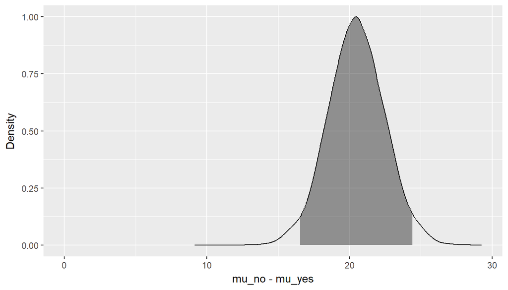

```r
bayes_inference(y=audience_score,x=drama,data=movies,statistic='mean',type='ht',alternative='twosided',null=0)
```

```
## Response variable: numerical, Explanatory variable: categorical (2 levels)
## n_no = 346, y_bar_no = 59.7312, s_no = 21.2775
## n_yes = 305, y_bar_yes = 65.3475, s_yes = 18.5418
## (Assuming intrinsic prior on parameters)
## Hypotheses:
## H1: mu_no  = mu_yes
## H2: mu_no != mu_yes
##
## Priors:
## P(H1) = 0.5
## P(H2) = 0.5
##
## Results:
## BF[H2:H1] = 22.6567
## P(H1|data) = 0.0423
## P(H2|data) = 0.9577
```

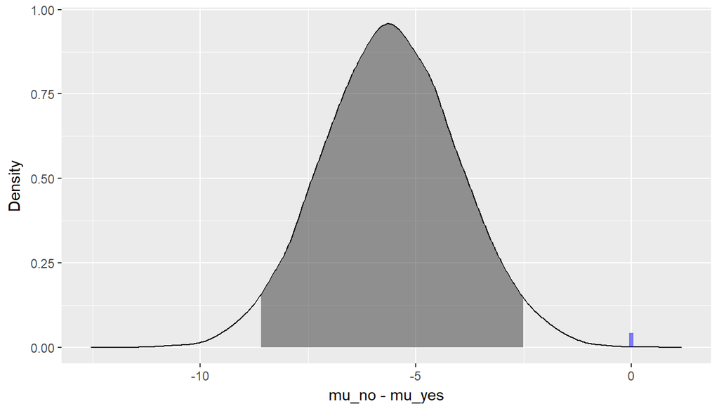

The modelling objective is to predict the popularity of a movie as indicated by audience_score and **optimize it with the most optimum set of variables while not sacricifing too much on accuracy** . We use function ‘stepAIC’ to optimize the lm model ‘lm_mod’ output produced earlier.

As default, the code below does a backward reduction using minimization of AIC scores as a criteria and arrives at a reduced set of influencor variables.

```r
lm_optim <- stepAIC(lm_mod,trace=FALSE,k=2)
lm_optim$anova
```

```
## Stepwise Model Path
## Analysis of Deviance Table
##
## Initial Model:
## audience_score ~ feature_film + drama + mpaa_rating_R + oscar_season +
##     summer_season + runtime + thtr_rel_year + imdb_rating + imdb_num_votes +
##     critics_score + best_pic_nom + best_pic_win + best_actor_win +
##     best_actress_win + best_dir_win + top200_box
##
## Final Model:
## audience_score ~ mpaa_rating_R + runtime + thtr_rel_year + imdb_rating +
##     critics_score + best_pic_nom + best_actor_win + best_actress_win
##
##
##               Step Df   Deviance Resid. Df Resid. Dev      AIC
## 1                                      633   62989.66 3006.940
## 2     - top200_box  1   9.240822       634   62998.90 3005.035
## 3   - oscar_season  1  26.461061       635   63025.36 3003.308
## 4   - best_pic_win  1  45.744109       636   63071.11 3001.780
## 5   - best_dir_win  1  93.998979       637   63165.11 3000.748
## 6  - summer_season  1 166.872376       638   63331.98 3000.463
## 7   - feature_film  1 155.730073       639   63487.71 3000.059
## 8          - drama  1 121.355602       640   63609.06 2999.300
## 9 - imdb_num_votes  1 147.829088       641   63756.89 2998.809
```

This reduces the model to:

**Model (reduced to 8 variables now):**

**audience_score** ~ mpaa_rating_R + runtime + thtr_rel_year + imdb_rating + critics_score + best_pic_nom + best_actor_win + best_actress_win

**while bringing down AIC from 3006.94 to 2998.80.**

As a next step to validate my results from stepAIC above, I have also used bayesian linear regression model using the same initial predictor variables. BAS provides several algorithms to sample from posterior distribution models for use in BMA or model selection. MCMC is recommended where enumeration is not possible. Zellner-Siow Cauchy distribution is used to assign prior distribution for regression coefficients. A uniform distribution is used for the prior probabilities for all models.

```r
# remove values with 'NA' in runtime variable
colSums(is.na(movies))
```

```
##   audience_score     feature_film            drama    mpaa_rating_R
##                0                0                0                0
##     oscar_season    summer_season          runtime    thtr_rel_year
##                0                0                1                0
##      imdb_rating   imdb_num_votes    critics_score     best_pic_nom
##                0                0                0                0
##     best_pic_win   best_actor_win best_actress_win     best_dir_win
##                0                0                0                0
##       top200_box
##                0
```

```r
movies <- na.omit(movies)

mov_basLM <- bas.lm(audience_score ~ ., data=movies, method='MCMC', prior='ZS-null', modelprior=uniform())
summary(mov_basLM)
```

```
##                     P(B != 0 | Y)  model 1     model 2     model 3
## Intercept              1.00000000   1.0000   1.0000000   1.0000000
## feature_filmyes        0.06762009   0.0000   0.0000000   0.0000000
## dramayes               0.04560394   0.0000   0.0000000   0.0000000
## mpaa_rating_Ryes       0.20166855   0.0000   0.0000000   0.0000000
## oscar_seasonyes        0.07773285   0.0000   0.0000000   0.0000000
## summer_seasonyes       0.08209000   0.0000   0.0000000   0.0000000
## runtime                0.46144485   0.0000   1.0000000   0.0000000
## thtr_rel_year          0.09614487   0.0000   0.0000000   0.0000000
## imdb_rating            0.99998474   1.0000   1.0000000   1.0000000
## imdb_num_votes         0.06089325   0.0000   0.0000000   0.0000000
## critics_score          0.87955170   1.0000   1.0000000   1.0000000
## best_pic_nomyes        0.13621597   0.0000   0.0000000   0.0000000
## best_pic_winyes        0.04259109   0.0000   0.0000000   0.0000000
## best_actor_winyes      0.14735031   0.0000   0.0000000   1.0000000
## best_actress_winyes    0.14267731   0.0000   0.0000000   0.0000000
## best_dir_winyes        0.06939240   0.0000   0.0000000   0.0000000
## top200_boxyes          0.04896851   0.0000   0.0000000   0.0000000
## BF                             NA   1.0000   0.8702806   0.2236679
## PostProbs                      NA   0.1419   0.1191000   0.0324000
## R2                             NA   0.7525   0.7549000   0.7539000
## dim                            NA   3.0000   4.0000000   4.0000000
## logmarg                        NA 443.9495 443.8105657 442.4519125
##                         model 4     model 5
## Intercept             1.0000000   1.0000000
## feature_filmyes       0.0000000   0.0000000
## dramayes              0.0000000   0.0000000
## mpaa_rating_Ryes      1.0000000   1.0000000
## oscar_seasonyes       0.0000000   0.0000000
## summer_seasonyes      0.0000000   0.0000000
## runtime               0.0000000   1.0000000
## thtr_rel_year         0.0000000   0.0000000
## imdb_rating           1.0000000   1.0000000
## imdb_num_votes        0.0000000   0.0000000
## critics_score         1.0000000   1.0000000
## best_pic_nomyes       0.0000000   0.0000000
## best_pic_winyes       0.0000000   0.0000000
## best_actor_winyes     0.0000000   0.0000000
## best_actress_winyes   0.0000000   0.0000000
## best_dir_winyes       0.0000000   0.0000000
## top200_boxyes         0.0000000   0.0000000
## BF                    0.2217602   0.2055844
## PostProbs             0.0302000   0.0287000
## R2                    0.7539000   0.7563000
## dim                   4.0000000   5.0000000
## logmarg             442.4433468 442.3676066
```

The top 5 model variables are shown below in red/purple:

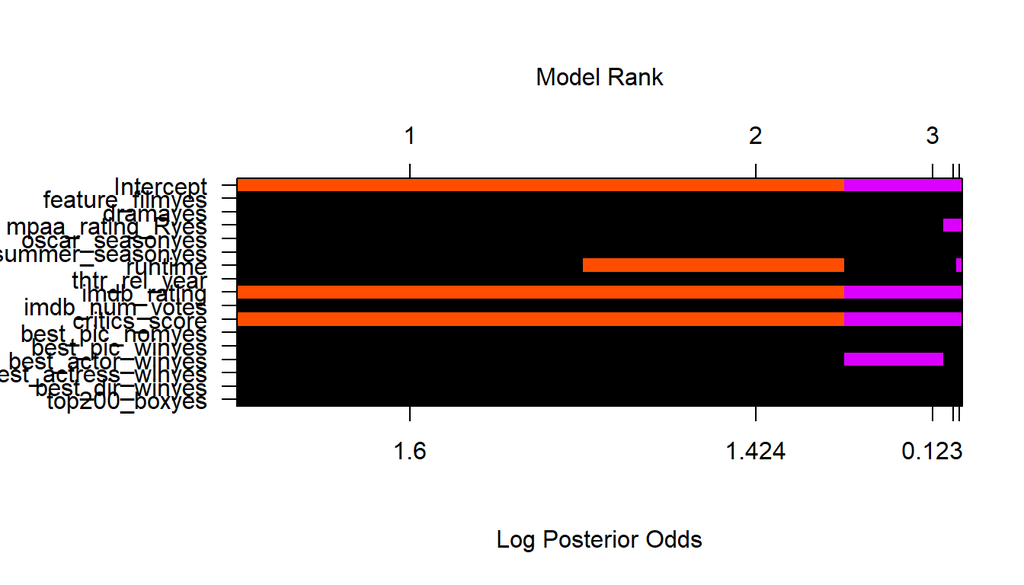

```r
image(mov_basLM,rotate=F,top.models=5)
```

The model image for top 5 variables shows: Intercept, mpaa_rating_R, imdb_rating, critics score and runtime as influencing variables .

*The residuals chart below shows a random distribution vs the fitted values. As seen, there are some outliers highlighted* The model probabilities (more than 6000 searches conducted) shows a leveling off after the initial ~600 searches. *The inclusion probabilities highlight the >0.5 values in red showing influencing variables as pointed out earlier from the model analysis

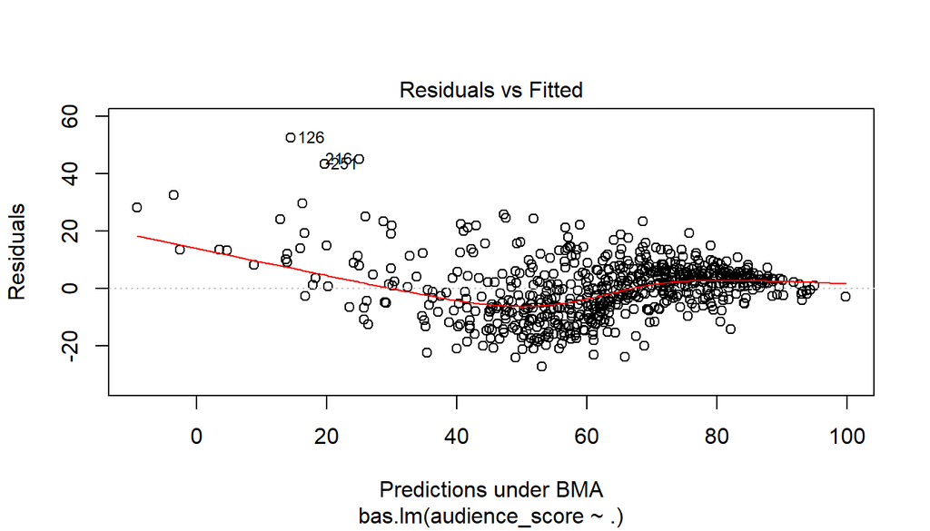

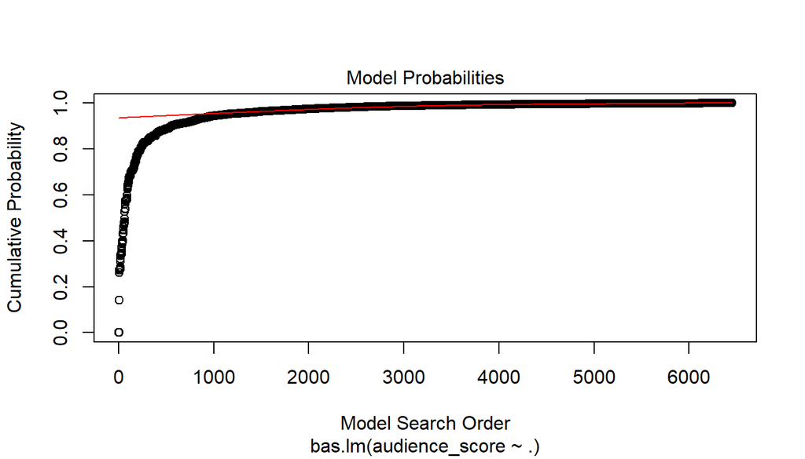

```r
plot(mov_basLM, which=c(1, 2), ask=FALSE)
```

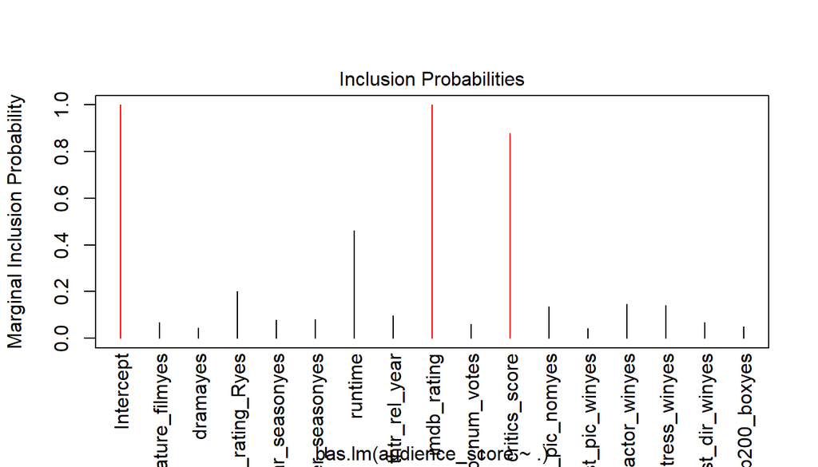

```r
plot(mov_basLM, which=4, ask=FALSE)
```

The posterior probability distribution is provided below for the important variables, showing a very concentrated mass, uni-modal for all variables * * *

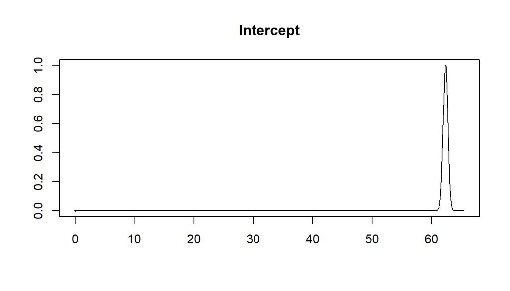

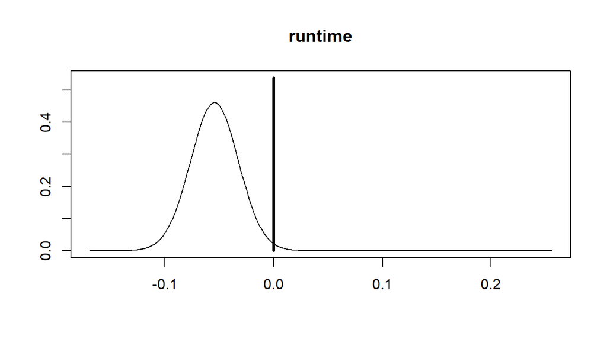

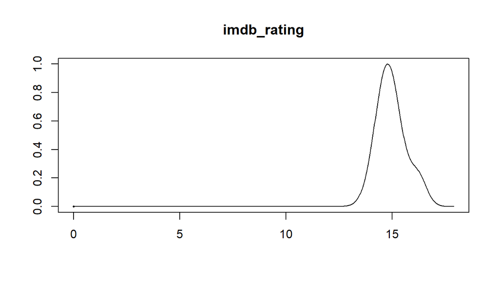

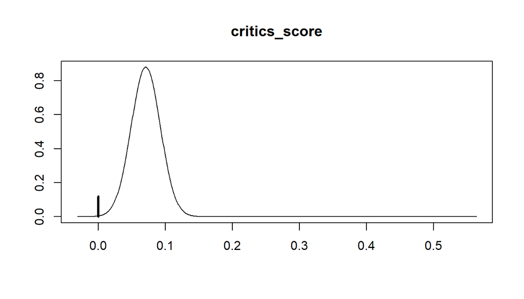

```r
plot(coefficients(mov_basLM), subset=c(1, 7,9,11), ask=FALSE)
```

As next step, I have rerun the basLM model with the now reduced set of variables to obtain the final model for prediction.

```r
final_basLM <- bas.lm(audience_score ~ imdb_rating+runtime+critics_score, data=movies, method='MCMC', prior='ZS-null', modelprior=uniform())
summary(final_basLM)
```

```
##               P(B != 0 | Y)  model 1     model 2     model 3     model 4
## Intercept           1.00000   1.0000   1.0000000   1.0000000   1.0000000
## imdb_rating         0.96875   1.0000   1.0000000   1.0000000   1.0000000
## runtime             0.43750   0.0000   1.0000000   1.0000000   0.0000000
## critics_score       0.85000   1.0000   1.0000000   0.0000000   0.0000000
## BF                       NA   1.0000   0.8702806   0.1275819   0.1142849
## PostProbs                NA   0.4688   0.3500000   0.0875000   0.0625000
## R2                       NA   0.7525   0.7549000   0.7509000   0.7481000
## dim                      NA   3.0000   4.0000000   3.0000000   2.0000000
## logmarg                  NA 443.9495 443.8105657 441.8905087 441.7804447
##                    model 5
## Intercept     1.000000e+00
## imdb_rating   0.000000e+00
## runtime       0.000000e+00
## critics_score 1.000000e+00
## BF            3.900438e-99
## PostProbs     3.120000e-02
## R2            4.958000e-01
## dim           2.000000e+00
## logmarg       2.173547e+02
```

The plots are repeated below for the reduced model

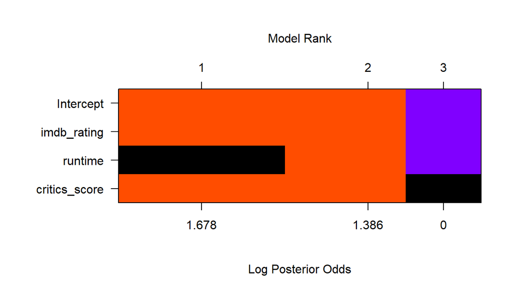

```r
image(final_basLM,rotate=F,top.model=3)
```

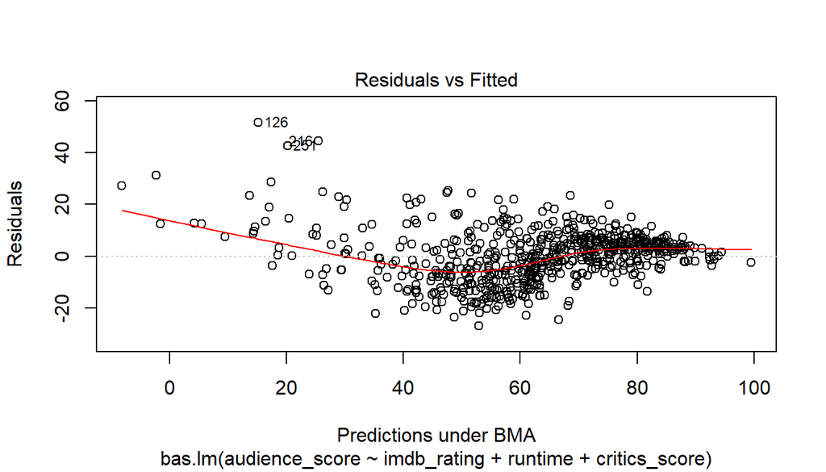

```r
plot(final_basLM, which=1, ask=FALSE)
```

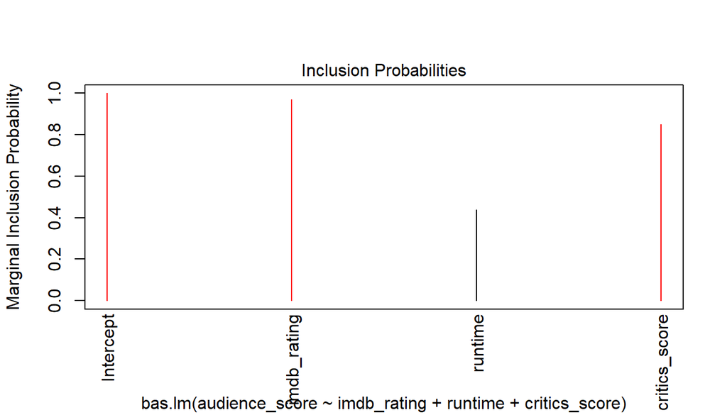

```r
#plot (final_basLM,which=3, ask=FALSE)
plot(final_basLM, which=4, ask=FALSE)
```

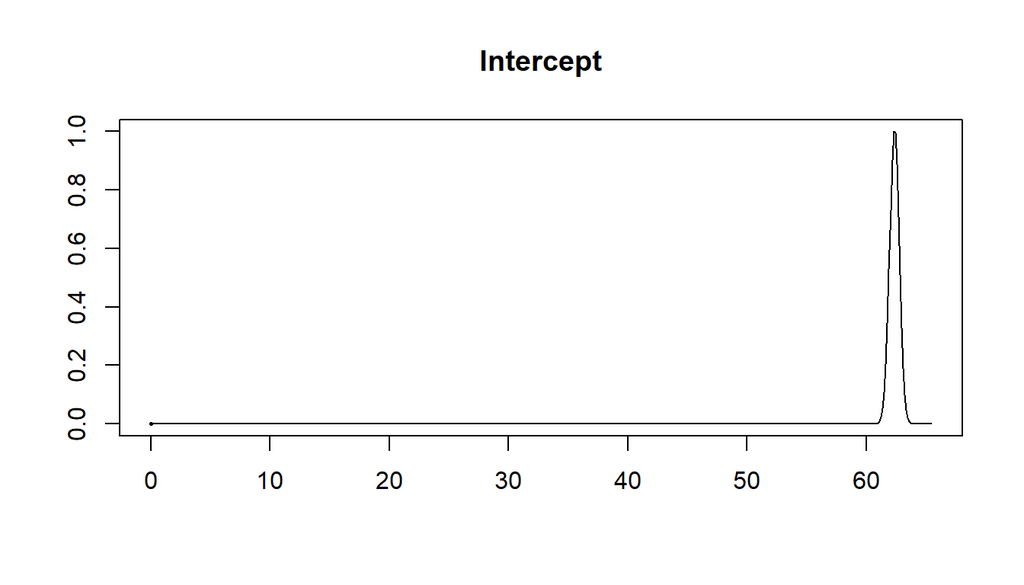

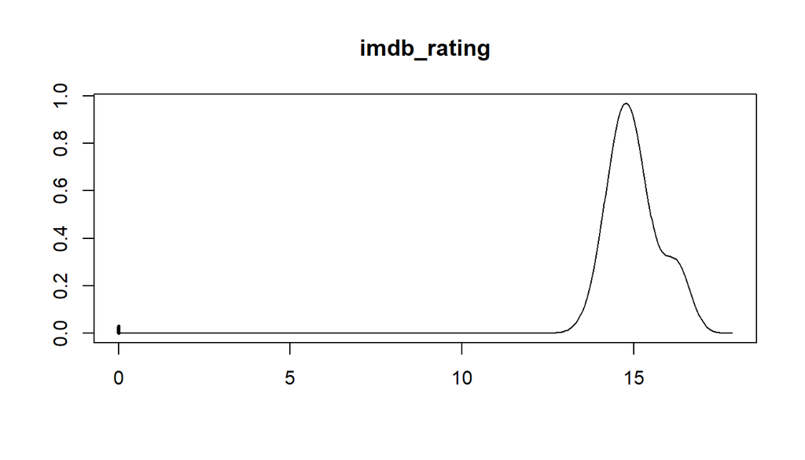

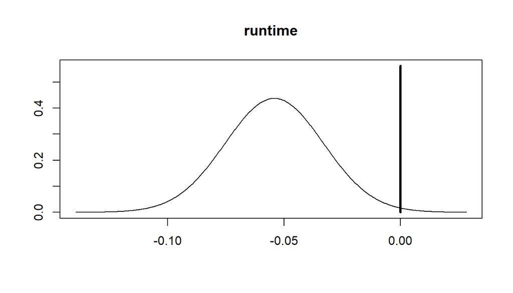

```r
plot(coefficients(final_basLM), subset=c(1, 2,3), ask=FALSE)
```

## Part 5: Prediction

I will use the final model to predict audience scores for the 2016 movie ’Passengers.

I start by creating a single data record for the movie with an audience_score of 63.

The code below creates a data frame taking the variable values from the 2 databases. We use the final model ‘final_basLM’ created with the optimized set of variables to predict audience_score and compare it to the actual audience score value taken from the database

```r
passenger2016 <- data.frame(runtime=116, thtr_rel_year=2016, imdb_rating=7, imdb_num_votes=247748, critics_score=41,
                         audience_score=63, best_pic_nom='no',best_pic_win='no',best_actor_win='no',
                         best_actress_win='no',best_dir_win='no',top200_box='no',feature_film='yes',drama='yes',
                         mpaa_rating_R='no',oscar_season='yes',summer_season='no')


# Get the prediction
pass_predict <- predict(final_basLM, newdata=passenger2016, estimator="BMA", se.fit=TRUE)

df <- data.frame(m='Passenger', p=sprintf("%2.1f", pass_predict$Ybma), k=sprintf("%2.1f",passenger2016$audience_score))
colnames(df) <- c('Movie Title', 'Predicted audience score', 'Actual audience score')

print(df)
```

```
##   Movie Title Predicted audience score Actual audience score
## 1   Passenger                     68.3                  63.0
```

```r
confint(pass_predict,estimation='BMA')
```

```
##          2.5%   97.5%     pred
## [1,] 47.45216 88.9008 68.25953
## attr(,"Probability")
## [1] 0.95
## attr(,"class")
## [1] "confint.bas"
```

I have also shown the prediction for audience scores using the full Bayes model, (before we reduced the explanatory variables down to 3 from 16). The prediction is also pretty close to that from the optimized model.

This brings out the fact that the model is now much simpler and the prediction accuracy has not gone down much.

```r
mov_predict <- predict(mov_basLM, newdata=passenger2016, estimator="BMA", se.fit=TRUE)

df <- data.frame(m="Passenger", p=sprintf("%2.1f", mov_predict$Ybma), k=sprintf("%2.1f",passenger2016$audience_score))
colnames(df) <- c("Movie Title", "Predicted Rating", "Actual Rating")

print(df)
```

```
##   Movie Title Predicted Rating Actual Rating
## 1   Passenger             68.8          63.0
```

```r
confint(mov_predict,estimation='BMA')
```

```
##          2.5%    97.5%     pred
## [1,] 49.14686 88.84036 68.75224
## attr(,"Probability")
## [1] 0.95
## attr(,"class")
## [1] "confint.bas"
```

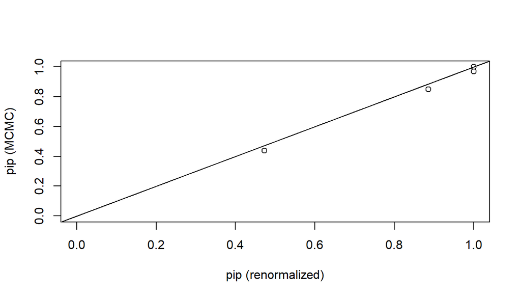

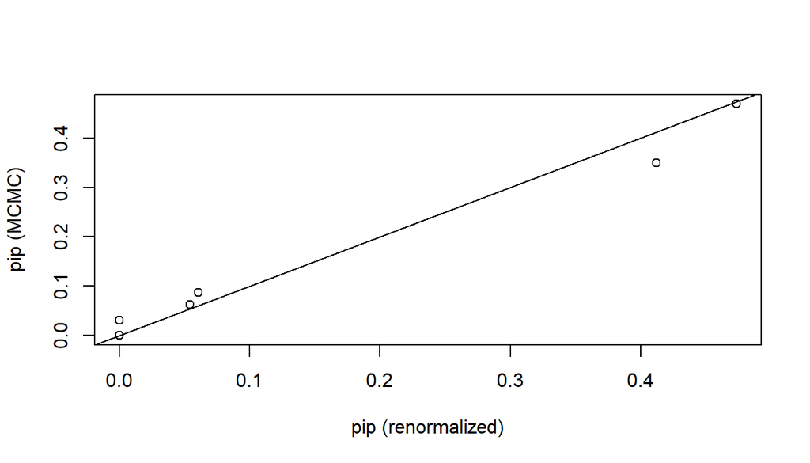

```r
diagnostics(final_basLM)
```

## Part 6: Conclusion

The Bayseaon model is richer in providing probabilities to help make better decisions on how to optimize. The analysis can further be improved by considering suitable treatment of outliers.